# Some equations that describe beautiful curves

Ivan Viveros

May 2020

## Introduction

In this document, I collect some equations that generate curves that I like.

If you like mathematical art, I would recommend looking at the work of [Hamid Naderi Yeganeh](https://twitter.com/naderi_yeganeh), who builds beautiful images based on mathematical concepts.

## The butterfly curve

The butterfly curve is defined in the paper by Fay (1989). This curve is described according to the following parametric equations:

$x=sin(t)\Big(e^{cos(t)}-2 \, cos(4t)-sin^5\big(\frac{t}{12}\big)\Big)$

$y=cos(t)\Big(e^{cos(t)}-2 \,cos(4t)-sin^5\big(\frac{t}{12}\big)\Big)$

*t* is in the range: $[0, 12\pi]$

```r
# the function butterfly generates a data frame
# by evaluating the parametric equations that
# define the rose curve in the range of 0 to 12pi
butterfly <- function(n=1000){
  data.frame(t = seq(0,12*pi,length.out = n)) %>%
    mutate(x = sin(t)*(exp(cos(t))-2*cos(4*t)-(sin(t/12))^5),
           y = cos(t)*(exp(cos(t))-2*cos(4*t)-(sin(t/12))^5))
}
```

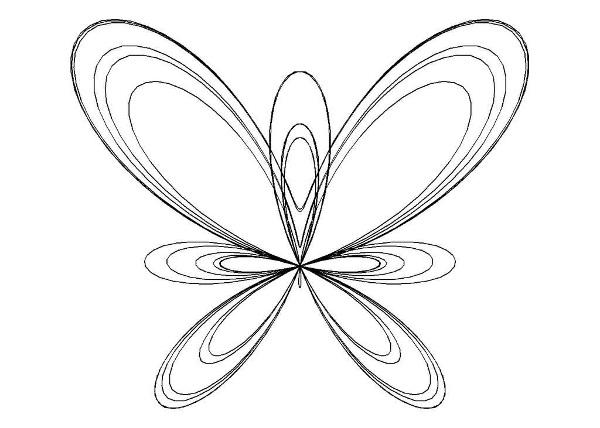

Figure 1: The butterfly curve (Fay, 1989)

```r
# Plot a butterfly curve
df_butter <- butterfly()

df_butter %>% ggplot() + geom_path(data = df_butter,aes(x,y)) + coord_equal() +
  theme_void()
```

## The rose

This curve is described by the following parametric equations:

$x=cos(k \, \theta) \, cos(\theta)$

$y=cos(k \, \theta) \, sin(\theta)$

```r
rose_curve <- function(n,d) {
  data.frame(theta = seq(0, 32*pi,pi/180)) %>%
    mutate(x = cos(n/d*theta)*cos(theta),
           y = cos(n/d*theta)*sin(theta)) %>%
    select(x, y)
}
```

Rose curves for the combination of *n* and *d* values, which define $k=n/d$.

*n* and *d* span in the range $[1,10]$

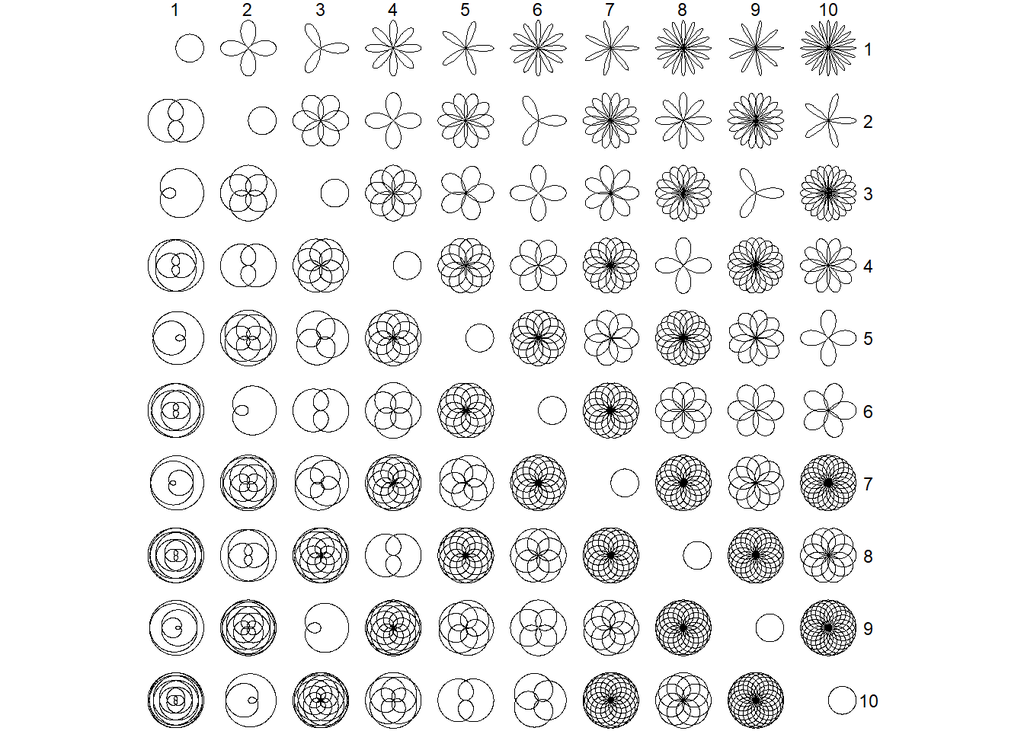

Figure 2: Rose curves

```r
df_rose <- data.frame(x = numeric(0), y = numeric(0), n = integer(0), d = integer(0))

for(n in 1:10) {
  for(d in 1:10) {
    df_temporary <- rose_curve(n, d) %>% mutate(n = n, d = d)
    df_rose <- rbind(df_rose, df_temporary)
  }
}

p <- ggplot() +
  geom_path(aes(x, y), df_rose, size = 0.35, lineend = "round") + facet_grid(d ~ n) +
  coord_equal() + theme_void()

p
```

## Hypocycloids

Refer to the [Wolfram MathWorld article](https://mathworld.wolfram.com/Hypocycloid.html) for details about hypocycloids.

When $x(0)=a$, the parametric equations defining the hypocycloid are:

$x=(a-b)\,cos(t) + b\,cos\big(\frac{a-b}{b}t\big)$

$y=(a-b)\,sin(t) - b\,sin\big(\frac{a-b}{b}t\big)$

```r
hypocycloid <- function(n = 200, a_inc,b_inc,t_inc){
  a0 = seq(1,n)
  b0 = seq(1,n)
  t0 = seq(0,n-1)
  for (i in 2:n) {
    a0[i]=a0[i-1]+a_inc
    b0[i]=b0[i-1]+b_inc
    t0[i]=t0[i-1]+t_inc
  }
  data.frame(a0,b0,t0) %>%
    mutate(  x0 = (a0 - b0)*cos(t0) + b0 * cos((a0/b0-1)*t0),
             y0 = (a0 - b0)*sin(t0) - b0 * sin((a0/b0-1)*t0),
             x1 = c(x0[2:n],x0[1]),
             y1 = c(y0[2:n],y0[1])) %>%
    select(x0,y0,x1,y1,t0)
}
```

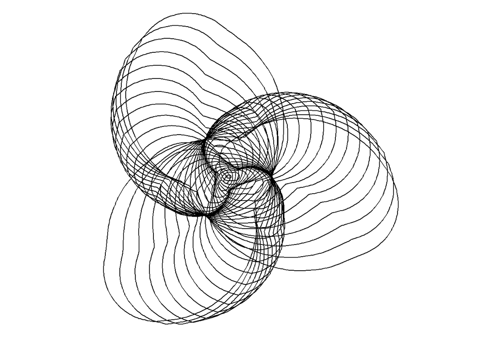

Figure 3: A hypocycloid

```r
# Uncomment the following lines so the parameters take random values.

# a_inc <- sample(seq(-100,100),1,replace=TRUE)/10
# b_inc <- sample(seq(-100,100),1,replace=TRUE)/10
# t_inc <- sample(seq(-100,100),1,replace=TRUE)/10

# I particulary like the plot generated by the following set of parameters
a_inc <- 1.9
b_inc <- 6.3
t_inc <- -7


df_hypo <- hypocycloid(a_inc = a_inc,b_inc = b_inc,t_inc = t_inc)

df_hypo %>% ggplot(aes(x=x0,y=y0)) +
  geom_curve(aes(xend=x1,yend=y1)) +
  scale_x_continuous(expand = c(0.1,0.1)) +
  scale_y_continuous(expand = c(0.1,0.1)) +
  coord_equal() +
  theme_void()
```

## Clifford attractors

Clifford attractors are defined by the following equations:

$x_{n+1}=sin(a\,y_n) + c\, cos(a\,x_n)$

$y_{n+1}=sin(b\,x_n) + d\, cos(b\,y_n)$

The above equations determine the *(X,Y)* locations of discrete steps of a particle starting from point *(x<sub>0</sub>,y<sub>0</sub>)* and according to the parameters *a*, *b*, *c* and *d*.

The function `pickover` is based on the implementation of [Antonio Sánchez Chinchón](https://fronkonstin.com/about/). The only difference is that `pickover` is based enterily on R, whereas Sánchez Chinchón defined his function in C++ by means of the `rcpp` package.

```r
# n is set to 1M
# a, b, c and d are the parameters of the equations
pickover <- function(n=10000000,a,b,c,d){
  x <- vector("numeric", n)
  y <- vector("numeric", n)
  x[1] <- 0
  y[1] <- 0
  for(i in 2:n) {
    x[i] <- sin(a * y[i-1]) + c * cos(a * x[i-1])
    y[i] <- sin(b * x[i-1]) + d * cos(b * y[i-1])
  }
  df <- data.frame(x = x, y = y)
}
```

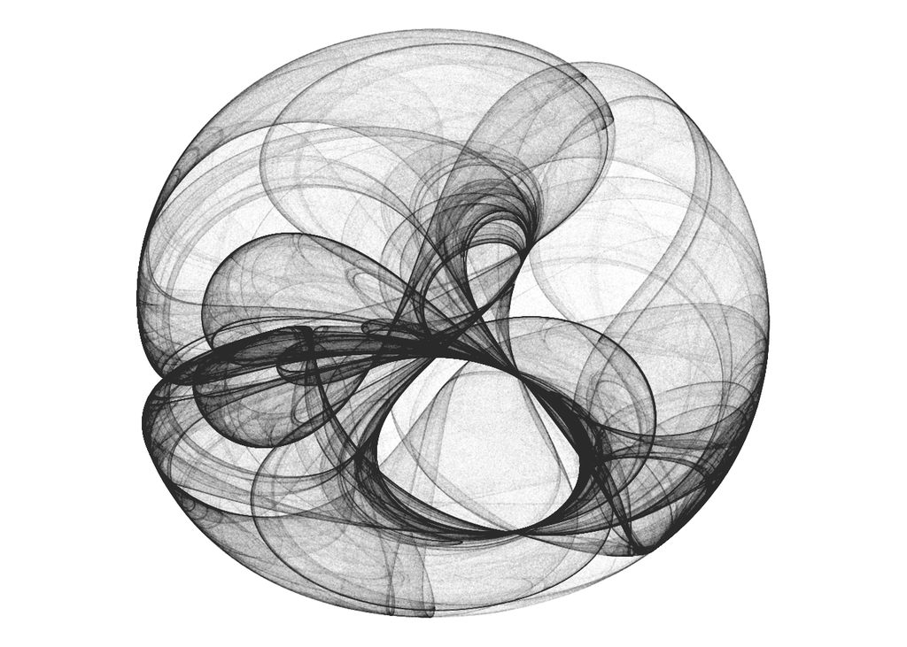

Figure 4: A plot defined by Clifford attractors

```r
# Set the values of the parameters
a = 1.2516757480973668; b = -1.1851629292227903; c = 1.4603558653849573; d = -1.3708149174574649

df_clifford <- pickover(a=a,b=b,c=c,d=d)

df_clifford %>% ggplot(aes(x, y)) +
  geom_point(color="black", shape=46, alpha=.01) + coord_equal() + theme_void()
```

## References

Fay, Temple H. 1989. “The Butterfly Curve.” Journal Article. *The American Mathematical Monthly* 96 (5): 442–43. https://doi.org/10.1080/00029890.1989.11972217.